# 13주차

Hosub Park

2016년 6월 8일

## <13주차>

### 1. Use the prostate data with lpsa as the response and the other variables as predictors. Implement the following variable selection methods to determine the “best” model:

```r
library(faraway)
library(leaps)
data("prostate")
```

#### (a) Backward Elimination

```r
mdl <- lm(lpsa~., data=prostate)
summary(mdl)
```

```
##
## Call:
## lm(formula = lpsa ~ ., data = prostate)
##
## Residuals:
##     Min      1Q  Median      3Q     Max
## -1.7331 -0.3713 -0.0170  0.4141  1.6381
##
## Coefficients:
##              Estimate Std. Error t value Pr(>|t|)
## (Intercept)  0.669337   1.296387   0.516  0.60693
## lcavol       0.587022   0.087920   6.677 2.11e-09 ***
## lweight      0.454467   0.170012   2.673  0.00896 **
## age         -0.019637   0.011173  -1.758  0.08229 .
## lbph         0.107054   0.058449   1.832  0.07040 .
## svi          0.766157   0.244309   3.136  0.00233 **
## lcp         -0.105474   0.091013  -1.159  0.24964
## gleason      0.045142   0.157465   0.287  0.77503
## pgg45        0.004525   0.004421   1.024  0.30886
## ---
## Signif. codes:  0 '***' 0.001 '**' 0.01 '*' 0.05 '.' 0.1 ' ' 1
##
## Residual standard error: 0.7084 on 88 degrees of freedom
## Multiple R-squared:  0.6548, Adjusted R-squared:  0.6234
## F-statistic: 20.86 on 8 and 88 DF,  p-value: < 2.2e-16
```

```r
mdl1 <- update(mdl, ~.-gleason, data=prostate)
summary(mdl1)
```

```
##
## Call:
## lm(formula = lpsa ~ lcavol + lweight + age + lbph + svi + lcp +
##     pgg45, data = prostate)
##
## Residuals:
##      Min       1Q   Median       3Q      Max
## -1.73117 -0.38137 -0.01728  0.43364  1.63513
##
## Coefficients:
##              Estimate Std. Error t value Pr(>|t|)
## (Intercept)  0.953926   0.829439   1.150  0.25319
## lcavol       0.591615   0.086001   6.879 8.07e-10 ***
## lweight      0.448292   0.167771   2.672  0.00897 **
## age         -0.019336   0.011066  -1.747  0.08402 .
## lbph         0.107671   0.058108   1.853  0.06720 .
## svi          0.757734   0.241282   3.140  0.00229 **
## lcp         -0.104482   0.090478  -1.155  0.25127
## pgg45        0.005318   0.003433   1.549  0.12488
## ---
## Signif. codes:  0 '***' 0.001 '**' 0.01 '*' 0.05 '.' 0.1 ' ' 1
##
## Residual standard error: 0.7048 on 89 degrees of freedom
## Multiple R-squared:  0.6544, Adjusted R-squared:  0.6273
## F-statistic: 24.08 on 7 and 89 DF,  p-value: < 2.2e-16
```

```r
mdl2 <- update(mdl1, ~.-lcp)
summary(mdl2)
```

```
##
## Call:
## lm(formula = lpsa ~ lcavol + lweight + age + lbph + svi + pgg45,
##     data = prostate)
##
## Residuals:
##      Min       1Q   Median       3Q      Max
## -1.77711 -0.41708  0.00002  0.40676  1.59681
##
## Coefficients:
##              Estimate Std. Error t value Pr(>|t|)
## (Intercept)  0.980085   0.830665   1.180  0.24116
## lcavol       0.545770   0.076431   7.141 2.31e-10 ***
## lweight      0.449450   0.168078   2.674  0.00890 **
## age         -0.017470   0.010967  -1.593  0.11469
## lbph         0.105755   0.058191   1.817  0.07249 .
## svi          0.641666   0.219757   2.920  0.00442 **
## pgg45        0.003528   0.003068   1.150  0.25331
## ---
## Signif. codes:  0 '***' 0.001 '**' 0.01 '*' 0.05 '.' 0.1 ' ' 1
##
## Residual standard error: 0.7061 on 90 degrees of freedom
## Multiple R-squared:  0.6493, Adjusted R-squared:  0.6259
## F-statistic: 27.77 on 6 and 90 DF,  p-value: < 2.2e-16
```

```r
mdl3 <- update(mdl2, ~.-pgg45)
summary(mdl3)
```

```
##
## Call:
## lm(formula = lpsa ~ lcavol + lweight + age + lbph + svi, data = prostate)
##
## Residuals:
##      Min       1Q   Median       3Q      Max
## -1.83505 -0.39396  0.00414  0.46336  1.57888
##
## Coefficients:
##             Estimate Std. Error t value Pr(>|t|)
## (Intercept)  0.95100    0.83175   1.143 0.255882
## lcavol       0.56561    0.07459   7.583 2.77e-11 ***
## lweight      0.42369    0.16687   2.539 0.012814 *
## age         -0.01489    0.01075  -1.385 0.169528
## lbph         0.11184    0.05805   1.927 0.057160 .
## svi          0.72095    0.20902   3.449 0.000854 ***
## ---
## Signif. codes:  0 '***' 0.001 '**' 0.01 '*' 0.05 '.' 0.1 ' ' 1
##
## Residual standard error: 0.7073 on 91 degrees of freedom
## Multiple R-squared:  0.6441, Adjusted R-squared:  0.6245
## F-statistic: 32.94 on 5 and 91 DF,  p-value: < 2.2e-16
```

```r
mdl4 <- update(mdl3, ~.-age)
summary(mdl4)
```

```
##
## Call:
## lm(formula = lpsa ~ lcavol + lweight + lbph + svi, data = prostate)
##
## Residuals:
##      Min       1Q   Median       3Q      Max
## -1.82653 -0.42270  0.04362  0.47041  1.48530
##
## Coefficients:
##             Estimate Std. Error t value Pr(>|t|)
## (Intercept)  0.14554    0.59747   0.244  0.80809
## lcavol       0.54960    0.07406   7.422 5.64e-11 ***
## lweight      0.39088    0.16600   2.355  0.02067 *
## lbph         0.09009    0.05617   1.604  0.11213
## svi          0.71174    0.20996   3.390  0.00103 **
## ---
## Signif. codes:  0 '***' 0.001 '**' 0.01 '*' 0.05 '.' 0.1 ' ' 1
##
## Residual standard error: 0.7108 on 92 degrees of freedom
## Multiple R-squared:  0.6366, Adjusted R-squared:  0.6208
## F-statistic: 40.29 on 4 and 92 DF,  p-value: < 2.2e-16
```

```r
mdl5 <- update(mdl4, ~.-lbph)
summary(mdl5)
```

```
##
## Call:
## lm(formula = lpsa ~ lcavol + lweight + svi, data = prostate)
##
## Residuals:
##      Min       1Q   Median       3Q      Max
## -1.72964 -0.45764  0.02812  0.46403  1.57013
##
## Coefficients:
##             Estimate Std. Error t value Pr(>|t|)
## (Intercept) -0.26809    0.54350  -0.493  0.62298
## lcavol       0.55164    0.07467   7.388  6.3e-11 ***
## lweight      0.50854    0.15017   3.386  0.00104 **
## svi          0.66616    0.20978   3.176  0.00203 **
## ---
## Signif. codes:  0 '***' 0.001 '**' 0.01 '*' 0.05 '.' 0.1 ' ' 1
##
## Residual standard error: 0.7168 on 93 degrees of freedom
## Multiple R-squared:  0.6264, Adjusted R-squared:  0.6144
## F-statistic: 51.99 on 3 and 93 DF,  p-value: < 2.2e-16
```

최초의 full model(`mdl`)과 비교해서 최종 model(`mdl5`)는 adjusted R^2 가 0.6234에서 0.6144로 매우 조금 감소하였지만 predictor의 수가 8개에서 3개로 감소하였고 모두 significant하다. 최종모델에 포함된 predictor는 `lcaol`, `lweight`, `svi`이다.

#### (b) AIC

```r
step(mdl)
```

```
## Start:  AIC=-58.32
## lpsa ~ lcavol + lweight + age + lbph + svi + lcp + gleason +
##     pgg45
##
##           Df Sum of Sq    RSS     AIC
## - gleason  1    0.0412 44.204 -60.231
## - pgg45    1    0.5258 44.689 -59.174
## - lcp      1    0.6740 44.837 -58.853
## <none>                 44.163 -58.322
## - age      1    1.5503 45.713 -56.975
## - lbph     1    1.6835 45.847 -56.693
## - lweight  1    3.5861 47.749 -52.749
## - svi      1    4.9355 49.099 -50.046
## - lcavol   1   22.3721 66.535 -20.567
##
## Step:  AIC=-60.23
## lpsa ~ lcavol + lweight + age + lbph + svi + lcp + pgg45
##
##           Df Sum of Sq    RSS     AIC
## - lcp      1    0.6623 44.867 -60.789
## <none>                 44.204 -60.231
## - pgg45    1    1.1920 45.396 -59.650
## - age      1    1.5166 45.721 -58.959
## - lbph     1    1.7053 45.910 -58.560
## - lweight  1    3.5462 47.750 -54.746
## - svi      1    4.8984 49.103 -52.037
## - lcavol   1   23.5039 67.708 -20.872
##
## Step:  AIC=-60.79
## lpsa ~ lcavol + lweight + age + lbph + svi + pgg45
##
##           Df Sum of Sq    RSS     AIC
## - pgg45    1    0.6590 45.526 -61.374
## <none>                 44.867 -60.789
## - age      1    1.2649 46.131 -60.092
## - lbph     1    1.6465 46.513 -59.293
## - lweight  1    3.5647 48.431 -55.373
## - svi      1    4.2503 49.117 -54.009
## - lcavol   1   25.4189 70.285 -19.248
##
## Step:  AIC=-61.37
## lpsa ~ lcavol + lweight + age + lbph + svi
##
##           Df Sum of Sq    RSS     AIC
## <none>                 45.526 -61.374
## - age      1    0.9592 46.485 -61.352
## - lbph     1    1.8568 47.382 -59.497
## - lweight  1    3.2251 48.751 -56.735
## - svi      1    5.9517 51.477 -51.456
## - lcavol   1   28.7665 74.292 -15.871
```

```
##
## Call:
## lm(formula = lpsa ~ lcavol + lweight + age + lbph + svi, data = prostate)
##
## Coefficients:
## (Intercept)       lcavol      lweight          age         lbph
##     0.95100      0.56561      0.42369     -0.01489      0.11184
##         svi
##     0.72095
```

최종모델은 AIC 값이 -61.37이다. 모두 5개의 predictor가 포함되었다. (`age`,`lbph`,`lweight`,`svi`, `lcavol`)

#### (c) Adjusted R2

```r
adr2 <- leaps(x=prostate[,c(1:8)], y=prostate$lpsa, method="adjr2")
maxadjr(adr2, 10)
```

```
##   1,2,3,4,5,6,8     1,2,3,4,5,8       1,2,3,4,5     1,2,3,4,5,7
##           0.627           0.626           0.625           0.624
## 1,2,3,4,5,6,7,8   1,2,3,4,5,6,7   1,2,3,4,5,7,8     1,2,3,4,5,6
##           0.623           0.623           0.622           0.621
##         1,2,4,5       1,2,4,5,8
##           0.621           0.620
```

가장 adjusted R^2가 높은 모델은 0.627의 값을 가지고 7개의 predictor를 포함한다. 그러나 adjusted R^2값이 높은 모델 중에서 제일 간단한 모델은 5개의 predictor를 포함한 3번째로 높은 adjusted R^2값을 가진 모델이다.

```r
names(prostate)[c(1,2,3,4,5)]
```

```
## [1] "lcavol"  "lweight" "age"     "lbph"    "svi"
```

#### (d) Mallows Cp

```r
cp <- leaps(x=prostate[,c(1:8)], y=prostate$lpsa, method="Cp")
```

구해진 각 모델의 Cp값과 p값의 관계를 그려보면,

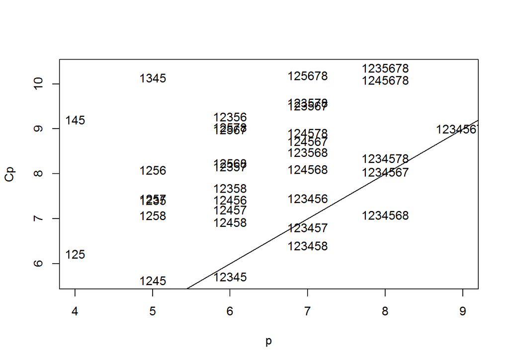

```r
Cpplot(leaps(x=prostate[,c(1:8)], y=prostate$lpsa))
```

Cp=p 의 선과 관계를 좀 더 보기 쉽게 나타내면,

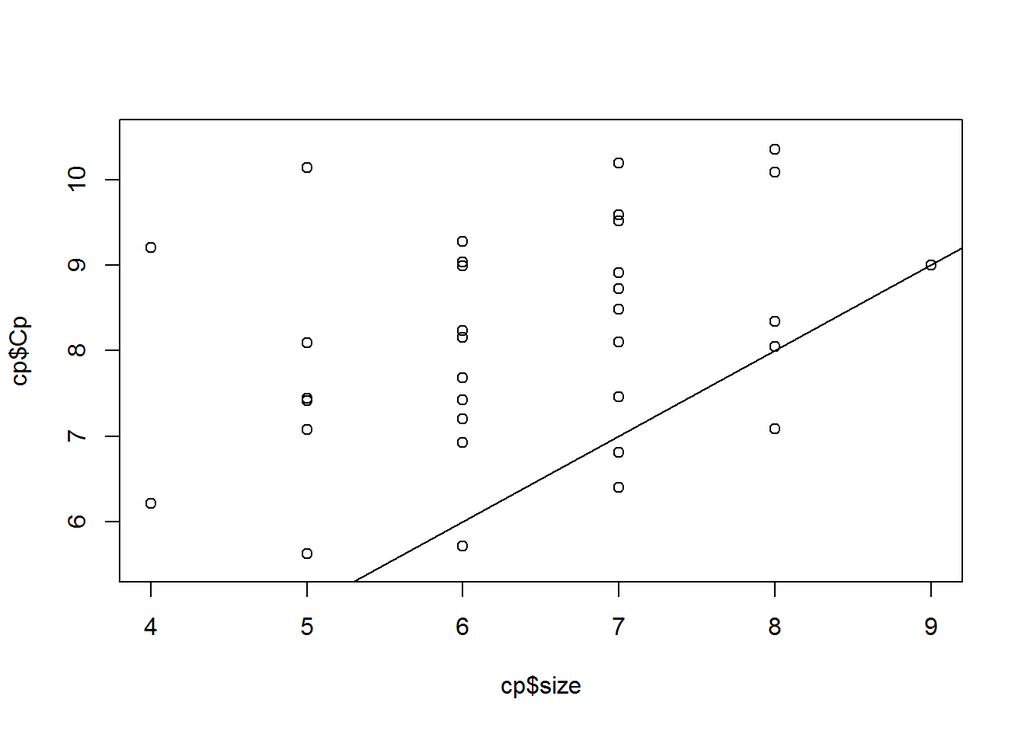

```r
plot(cp$Cp~cp$size, xlim=c(4,9),ylim=c(5.5,10.5))
abline(0,1)
```

여기서 Cp값이 p값에 가장 가까운 10개 모델을 뽑아보면,

```r
cpdf <-cbind(size=cp$size,cp$which,Cp=cp$Cp,cp_p=abs(cp$size-cp$Cp))
head(cpdf[order(cpdf[,11]),],10)
```

```
##   size 1 2 3 4 5 6 7 8       Cp       cp_p
## 8    9 1 1 1 1 1 1 1 1 9.000000 0.00000000
## 7    8 1 1 1 1 1 1 1 0 8.047624 0.04762397
## 6    7 1 1 1 1 1 0 1 0 6.806372 0.19362823
## 5    6 1 1 1 1 1 0 0 0 5.715016 0.28498396
## 7    8 1 1 1 1 1 0 1 1 8.343017 0.34301696
## 6    7 1 1 1 1 1 1 0 0 7.457430 0.45743034
## 6    7 1 1 1 1 1 0 0 1 6.401965 0.59803471
## 4    5 1 1 0 1 1 0 0 0 5.626422 0.62642197
## 7    8 1 1 1 1 1 1 0 1 7.082184 0.91781579
## 5    6 1 1 0 1 1 0 0 1 6.922392 0.92239202
```

```r
names(prostate[c(6,7,8)])
```

```
## [1] "lcp"     "gleason" "pgg45"
```

`lcp`, `gleason`, `pgg45`를 제외한 5개의 모델이 Cp=p에 근접하면서 제일 간단한 모델이므로 best model로 정한다.

### 2. Fit a linear model to the stackloss data with stack.loss as the predictor and the other variables as predictors. Simplify the model if possible. Check the model for outliers and influential points. Now return to the full model, determine whether there are any outliers or influential points, eliminate them and then repeat the variable selection procedures.

```r
data(stackloss)
mdl <- lm(stack.loss~., data=stackloss)
summary(mdl)
```

```
##
## Call:
## lm(formula = stack.loss ~ ., data = stackloss)
##
## Residuals:
##     Min      1Q  Median      3Q     Max
## -7.2377 -1.7117 -0.4551  2.3614  5.6978
##
## Coefficients:
##             Estimate Std. Error t value Pr(>|t|)
## (Intercept) -39.9197    11.8960  -3.356  0.00375 **
## Air.Flow      0.7156     0.1349   5.307  5.8e-05 ***
## Water.Temp    1.2953     0.3680   3.520  0.00263 **
## Acid.Conc.   -0.1521     0.1563  -0.973  0.34405
## ---
## Signif. codes:  0 '***' 0.001 '**' 0.01 '*' 0.05 '.' 0.1 ' ' 1
##
## Residual standard error: 3.243 on 17 degrees of freedom
## Multiple R-squared:  0.9136, Adjusted R-squared:  0.8983
## F-statistic:  59.9 on 3 and 17 DF,  p-value: 3.016e-09
```

### 단순화한 모델

`Acid.Conc`가 significant하지 않으므로 제외한다.

```r
mdl2 <- update(mdl, ~.-Acid.Conc., data=stackloss)
summary(mdl2)
```

```
##
## Call:
## lm(formula = stack.loss ~ Air.Flow + Water.Temp, data = stackloss)
##
## Residuals:
##     Min      1Q  Median      3Q     Max
## -7.5290 -1.7505  0.1894  2.1156  5.6588
##
## Coefficients:
##             Estimate Std. Error t value Pr(>|t|)
## (Intercept) -50.3588     5.1383  -9.801 1.22e-08 ***
## Air.Flow      0.6712     0.1267   5.298 4.90e-05 ***
## Water.Temp    1.2954     0.3675   3.525  0.00242 **
## ---
## Signif. codes:  0 '***' 0.001 '**' 0.01 '*' 0.05 '.' 0.1 ' ' 1
##
## Residual standard error: 3.239 on 18 degrees of freedom
## Multiple R-squared:  0.9088, Adjusted R-squared:  0.8986
## F-statistic: 89.64 on 2 and 18 DF,  p-value: 4.382e-10
```

Outlier판독

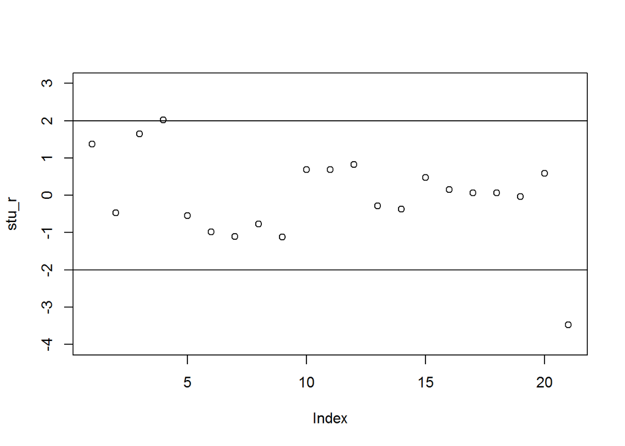

```r
library(car)

stu_r <- rstudent(mdl2)
plot(stu_r, ylim=c(-4,3))
abline(h=c(-2,2))
```

```r
which(abs(stu_r)>2)
```

```
##  4 21
##  4 21
```

4, 21 번째 observation이 outlier.

influential point 판독

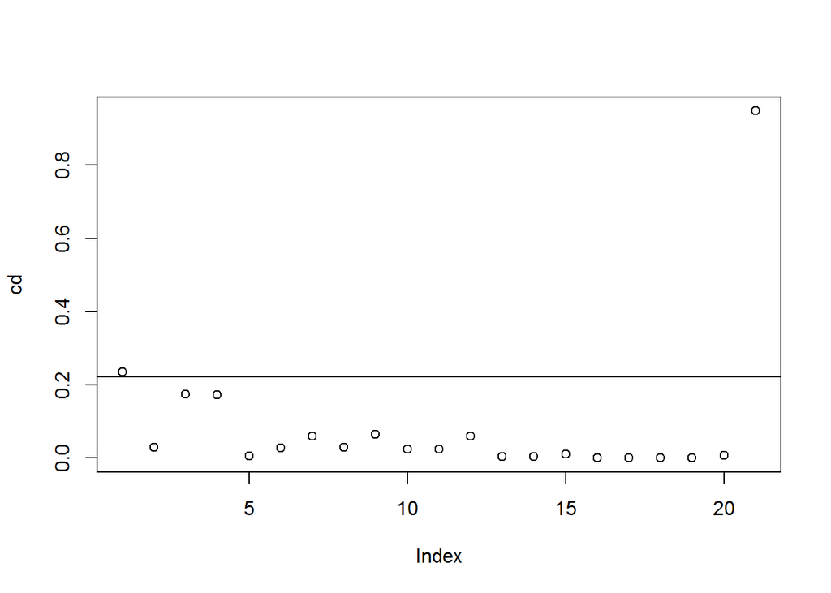

```r
cd <- cooks.distance(mdl2)

plot(cd)
abline(h=4/(21-2-1))
```

1, 21번째 observation이 high influential point

### Full model

Outlier판독

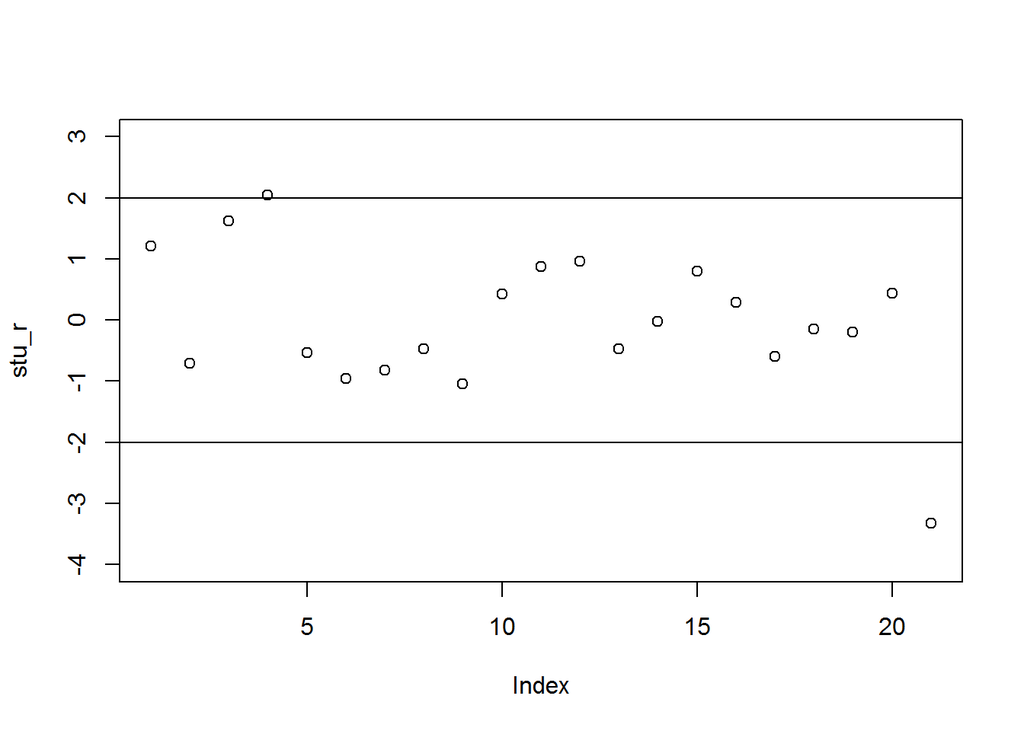

```r
stu_r <- rstudent(mdl)
plot(stu_r, ylim=c(-4,3))
abline(h=c(-2,2))
```

```r
which(abs(stu_r)>2)
```

```
##  4 21
##  4 21
```

4번째와 21번째가 outlier

influential point 판독

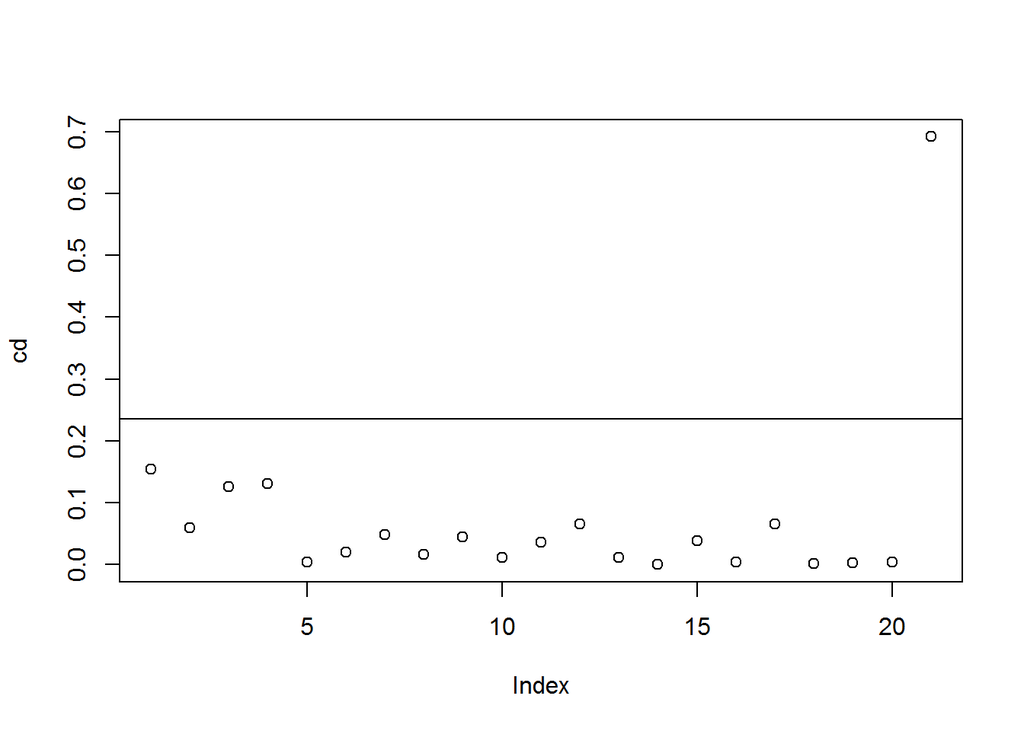

```r
cd <- cooks.distance(mdl)

plot(cd)
abline(h=4/(21-3-1))
```

21번째가 high influential point

21번째 observation은 studentized r값이 크고 cooks distance도 크므로 제외하고 modeling.

```r
mdl3 <- lm(stack.loss~. , data=stackloss, subset=-21)
summary(mdl3)
```

```
##
## Call:
## lm(formula = stack.loss ~ ., data = stackloss, subset = -21)
##
## Residuals:
##     Min      1Q  Median      3Q     Max
## -3.0449 -2.0578  0.1025  1.0709  6.3017
##
## Coefficients:
##             Estimate Std. Error t value Pr(>|t|)
## (Intercept) -43.7040     9.4916  -4.605 0.000293 ***
## Air.Flow      0.8891     0.1188   7.481 1.31e-06 ***
## Water.Temp    0.8166     0.3250   2.512 0.023088 *
## Acid.Conc.   -0.1071     0.1245  -0.860 0.402338
## ---
## Signif. codes:  0 '***' 0.001 '**' 0.01 '*' 0.05 '.' 0.1 ' ' 1
##
## Residual standard error: 2.569 on 16 degrees of freedom
## Multiple R-squared:  0.9488, Adjusted R-squared:  0.9392
## F-statistic: 98.82 on 3 and 16 DF,  p-value: 1.541e-10
```

`Acid.Conc.`를 제외

```r
mdl4 <- update(mdl3, ~.-Acid.Conc.)
summary(mdl4)
```

```
##
## Call:
## lm(formula = stack.loss ~ Air.Flow + Water.Temp, data = stackloss,
##     subset = -21)
##
## Residuals:
##     Min      1Q  Median      3Q     Max
## -2.9052 -2.2893  0.5151  1.0123  6.2916
##
## Coefficients:
##             Estimate Std. Error t value Pr(>|t|)
## (Intercept) -51.0760     4.0502 -12.611 4.69e-10 ***
## Air.Flow      0.8630     0.1140   7.568 7.70e-07 ***
## Water.Temp    0.8033     0.3222   2.493   0.0233 *
## ---
## Signif. codes:  0 '***' 0.001 '**' 0.01 '*' 0.05 '.' 0.1 ' ' 1
##
## Residual standard error: 2.549 on 17 degrees of freedom
## Multiple R-squared:  0.9464, Adjusted R-squared:  0.9401
## F-statistic: 150.2 on 2 and 17 DF,  p-value: 1.571e-11
```

21번째 observation제외하기 전과 비교

```r
summary(mdl2)
```

```
##
## Call:
## lm(formula = stack.loss ~ Air.Flow + Water.Temp, data = stackloss)
##
## Residuals:
##     Min      1Q  Median      3Q     Max
## -7.5290 -1.7505  0.1894  2.1156  5.6588
##
## Coefficients:
##             Estimate Std. Error t value Pr(>|t|)
## (Intercept) -50.3588     5.1383  -9.801 1.22e-08 ***
## Air.Flow      0.6712     0.1267   5.298 4.90e-05 ***
## Water.Temp    1.2954     0.3675   3.525  0.00242 **
## ---
## Signif. codes:  0 '***' 0.001 '**' 0.01 '*' 0.05 '.' 0.1 ' ' 1
##
## Residual standard error: 3.239 on 18 degrees of freedom
## Multiple R-squared:  0.9088, Adjusted R-squared:  0.8986
## F-statistic: 89.64 on 2 and 18 DF,  p-value: 4.382e-10
```

제거한 모델의 adjusted R squared 값이 더 크다.